# DATA 624 HW7

Bharani Nittala

April 2, 2023

```r
library(tidyverse)
library(caret)
library(DataExplorer)
library(RANN)
library(pls)
library(caret)
library(caTools)
library(Amelia)
```

# Homework 7: Linear Regression

## Instructions

In Kuhn and Johnson do problems 6.2 and 6.3. There are only two but they consist of many parts. Please submit a link to your Rpubs and submit the .rmd file as well.

### Exercise 6.2

Developing a model to predict permeability (see Sect. 1.4) could save significant resources for a pharmaceutical company, while at the same time more rapidly identifying molecules that have a sufficient permeability to become a drug:

**(a) Start R and use these commands to load the data:**

```r
library(AppliedPredictiveModeling)
data(permeability)
```

**The matrix `fingerprints` contains the 1,107 binary molecular predictors for the 165 compounds, while `permeability` contains permeability response.**

```r
dim(fingerprints)
```

```
## [1]  165 1107
```

```r
head(permeability)
```

```
##   permeability
## 1       12.520
## 2        1.120
## 3       19.405
## 4        1.730
## 5        1.680
## 6        0.510
```

**(b) The fingerprint predictors indicate the presence or absence of substructures of a molecule and are often sparse meaning that relatively few of the molecules contain each substructure. Filter out the predictors that have low frequencies using the `nearZeroVar` function from the `caret` package. How many predictors are left for modeling?**

```r
#719 low frequency instances
low_frequency <- nearZeroVar(fingerprints)

#remove low frequency columns using baser df[row,columns]
predictors <- fingerprints[,-low_frequency]

#388 predictors remaining
#dim(predictors)
```

After applying the `nerZeroVar` function and filtering out the low frequency predictors, we are left with 388 out of the original 1,107.

**(c) Split the data into a training and a test set, pre-process the data, and tune a `PLS` model. How many latent variables are optimal and what is the corresponding resampled estimate of R2?**

```r
set.seed(624)

#70 30 split
split1<- sample(c(rep(0, 0.7 * nrow(permeability)),
                  rep(1, 0.3 * nrow(permeability))))

#training split1[0] = 115 observations, test split1[1] = 49 observations
#table(split1)

X_train <- predictors[split1 == 0,]
X_test <- predictors[split1 == 1,]

y_train <- permeability[split1 == 0]
y_test <- permeability[split1 == 1]

#PLS model
plsTune <- train(X_train, y_train,
                method='pls', metric='Rsquared',
                tuneLength=20,
                trControl=trainControl(method='cv'),
                preProc=c('center', 'scale')
                )
plsTune
```

```
## Partial Least Squares
##
## 116 samples
## 388 predictors
##
## Pre-processing: centered (388), scaled (388)
## Resampling: Cross-Validated (10 fold)
## Summary of sample sizes: 104, 105, 105, 104, 104, 104, ...
## Resampling results across tuning parameters:
##
##   ncomp  RMSE      Rsquared   MAE
##    1     12.98974  0.3897237  10.091790
##    2     11.71406  0.5029046   8.701257
##    3     11.83257  0.5312902   9.214913
##    4     11.42981  0.5632994   9.013731
##    5     11.03805  0.5914051   8.691079
##    6     10.59821  0.6316227   8.231370
##    7     10.26537  0.6443277   7.986676
##    8     10.46235  0.6304089   8.231908
##    9     10.73985  0.6017092   8.546290
##   10     10.83152  0.5891046   8.531458
##   11     10.99323  0.5805043   8.418635
##   12     11.13834  0.5746015   8.593098
##   13     11.37617  0.5655660   8.816645
##   14     11.58639  0.5586207   9.061223
##   15     11.77675  0.5451381   9.186252
##   16     12.04135  0.5270379   9.397151
##   17     12.31818  0.5175956   9.491485
##   18     12.67136  0.4995409   9.714319
##   19     12.76746  0.4976270   9.845285
##   20     12.90804  0.4913546  10.027778
##
## Rsquared was used to select the optimal model using the largest value.
## The final value used for the model was ncomp = 7.
```

```r
plsTune$results %>%
  dplyr::filter(ncomp == 7)
```

```
##   ncomp     RMSE  Rsquared      MAE  RMSESD RsquaredSD    MAESD
## 1     7 10.26537 0.6443277 7.986676 2.36905  0.1930055 1.832539
```

The best tune was found at `ncomp` = 7 with an $R^2$ value of 0.6443277.

**(d) Predict the response for the test set. What is the test set estimate of R2?**

```r
#generate prediction using model and testing data
plsPred <- predict(plsTune, newdata=X_test)

#evaluation metrics
postResample(pred=plsPred, obs=y_test)
```

```
##      RMSE  Rsquared       MAE
## 15.504629  0.298245 10.263821
```

The predictions on the test set yield an R2 of 0.298, which is lower than the training set R2.

**(e) Try building other models discussed in this chapter. Do any have better predictive performance?**

We will try building a ridge regression and elastic net model, which use penalization to reduce RMSE.

```r
ridgeGrid <- data.frame(.lambda = seq(0, .1, length = 15))

enetGrid <- expand.grid(.lambda = c(0, 0.01, .1), .fraction = seq(.05, 1, length = 20))
```

```r
set.seed(100)
ridgeRegFit <- train(X_train, y_train,
method = "ridge",
## Fit the model over many penalty values
tuneGrid = ridgeGrid,
trControl = trainControl(method = "cv", number = 10),
## put the predictors on the same scale
preProc = c("center", "scale"))
```

```r
ridgeRegFit
```

```
## Ridge Regression
##
## 116 samples
## 388 predictors
##
## Pre-processing: centered (388), scaled (388)
## Resampling: Cross-Validated (10 fold)
## Summary of sample sizes: 104, 104, 104, 104, 105, 105, ...
## Resampling results across tuning parameters:
##
##   lambda       RMSE      Rsquared   MAE
##   0.000000000  13.42918  0.4350687   9.813896
##   0.007142857  13.39973  0.4347176  10.069807
##   0.014285714  12.79387  0.4595642   9.561699
##   0.021428571  12.57599  0.4709797   9.342162
##   0.028571429  12.36206  0.4822585   9.147202
##   0.035714286  12.24330  0.4896934   9.015106
##   0.042857143  12.16753  0.4945919   8.913440
##   0.050000000  12.08335  0.5004080   8.823110
##   0.057142857  12.02912  0.5045467   8.754285
##   0.064285714  11.97670  0.5086675   8.706204
##   0.071428571  11.92931  0.5120632   8.667938
##   0.078571429  11.89081  0.5151343   8.648102
##   0.085714286  11.87584  0.5175576   8.633921
##   0.092857143  11.84389  0.5198216   8.618253
##   0.100000000  11.82397  0.5223366   8.610166
##
## RMSE was used to select the optimal model using the smallest value.
## The final value used for the model was lambda = 0.1.
```

The ridge regression used an optimal penalty of lambda 0.1 which yielded a RMSE of 11.82.

```r
set.seed(100)
enetTune <- train(X_train, y_train,
method = "enet",
tuneGrid = enetGrid,
trControl = trainControl(method = "cv", number = 10),
preProc = c("center", "scale"))
```

```r
enetTune
```

```
## Elasticnet
##
## 116 samples
## 388 predictors
##
## Pre-processing: centered (388), scaled (388)
## Resampling: Cross-Validated (10 fold)
## Summary of sample sizes: 104, 104, 104, 104, 105, 105, ...
## Resampling results across tuning parameters:
##
##   lambda  fraction  RMSE      Rsquared   MAE
##   0.00    0.05      12.89447  0.4958656  10.098686
##   0.00    0.10      11.55344  0.5511241   8.709817
##   0.00    0.15      11.16136  0.5697351   8.310974
##   0.00    0.20      11.17919  0.5598754   8.223731
##   0.00    0.25      11.37140  0.5416571   8.265924
##   0.00    0.30      11.50593  0.5310362   8.390119
##   0.00    0.35      11.57897  0.5266347   8.490916
##   0.00    0.40      11.72109  0.5176938   8.560236
##   0.00    0.45      11.89539  0.5095340   8.657046
##   0.00    0.50      11.95153  0.5100184   8.684189
##   0.00    0.55      12.03194  0.5056331   8.765216
##   0.00    0.60      12.17967  0.4984503   8.896229
##   0.00    0.65      12.28237  0.4938369   9.005594
##   0.00    0.70      12.38252  0.4892529   9.099680
##   0.00    0.75      12.51270  0.4824588   9.189189
##   0.00    0.80      12.65010  0.4744044   9.264844
##   0.00    0.85      12.79513  0.4656540   9.346416
##   0.00    0.90      12.98995  0.4559565   9.475609
##   0.00    0.95      13.20659  0.4458025   9.637678
##   0.00    1.00      13.42918  0.4350687   9.813896
##   0.01    0.05      13.18297  0.4866818  10.007414
##   0.01    0.10      13.97323  0.5239471  10.743653
##   0.01    0.15      15.53625  0.5068019  12.194767
##   0.01    0.20      17.33769  0.4942749  13.633990
##   0.01    0.25      19.06313  0.4976596  15.010541
##   0.01    0.30      21.07059  0.4910393  16.488132
##   0.01    0.35      23.16569  0.4866973  17.963082
##   0.01    0.40      25.37782  0.4806392  19.491249
##   0.01    0.45      27.56591  0.4746575  20.960403
```

[output cut: 19 more lines]

```
##   0.10    0.45      11.07856  0.5482089   8.104849
##   0.10    0.50      11.06643  0.5487583   8.109480
##   0.10    0.55      11.10437  0.5473447   8.131812
##   0.10    0.60      11.14986  0.5456959   8.155057
##   0.10    0.65      11.19748  0.5446580   8.168515
##   0.10    0.70      11.28283  0.5420062   8.207598
##   0.10    0.75      11.37487  0.5389174   8.267045
##   0.10    0.80      11.47199  0.5346039   8.326146
##   0.10    0.85      11.56486  0.5308932   8.391362
##   0.10    0.90      11.67084  0.5268765   8.465233
##   0.10    0.95      11.75356  0.5243030   8.536928
##   0.10    1.00      11.82397  0.5223366   8.610166
##
## RMSE was used to select the optimal model using the smallest value.
## The final values used for the model were fraction = 0.15 and lambda = 0.1.
```

**(f) Would you recommend any of your models to replace the permeability laboratory experiment?**

```r
enetpredict <- predict(enetTune, X_test)

postResample(pred=enetpredict, obs = y_test)
```

```
##       RMSE   Rsquared        MAE
## 14.2854921  0.3158383  9.4547206
```

With an R2 of about 0.31 for the predictions on our test set from our best model, I don’t feel confident that we could replace the laboratory experiments with any of these models.

### Exercise 6.3

A chemical manufacturing process for a pharmaceutical product was discussed in Sect. 1.4. In this problem, the objective is to understand the relationship between biological measurements of the raw materials (predictors), measurements of the manufacturing process (predictors), and the response of product yield. Biological predictors cannot be changed but can be used to assess the quality of the raw material before processing. On the other hand, manufacturing process predictors can be changed in the manufacturing process. Improving product yield by 1 % will boost revenue by approximately one hundred thousand dollars per batch:

**(a) Start R and use these commands to load the data:**

```r
data("ChemicalManufacturingProcess")
```

**The matrix `processPredictors` contains the 57 predictors (12 describing the input biological material and 45 describing the process predictors) for the 176 manufacturing runs. `yield` contains the percent yield for each run.**

```r
dim(ChemicalManufacturingProcess)
```

```
## [1] 176  58
```

**(b) A small percentage of cells in the predictor set contain missing values. Use an imputation function to fill in these missing values (e.g., see Sect. 3.8).**

On the missing values plot below, we can observe that roughly 28 variables have missing values that range from 0.57% to 8.52% of values missing.

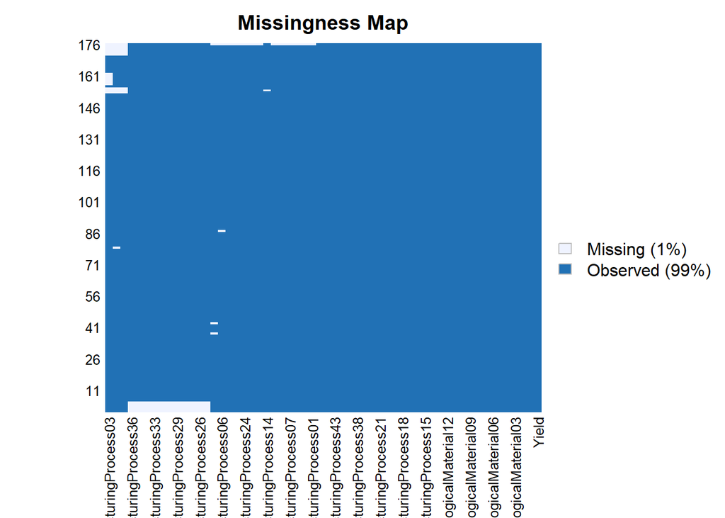

```r
library(AppliedPredictiveModeling)
missmap(ChemicalManufacturingProcess)
```

```r
#using knn imputation
(CHEM_knn_impute <- preProcess(ChemicalManufacturingProcess, method=c('knnImpute')))
```

```
## Created from 152 samples and 58 variables
##
## Pre-processing:
##   - centered (58)
##   - ignored (0)
##   - 5 nearest neighbor imputation (58)
##   - scaled (58)
```

```r
CHEM_dataframe <- predict(CHEM_knn_impute, ChemicalManufacturingProcess)
summary(CHEM_dataframe)
```

```
##      Yield         BiologicalMaterial01 BiologicalMaterial02
##  Min.   :-2.6692   Min.   :-2.5653      Min.   :-2.1858
##  1st Qu.:-0.7716   1st Qu.:-0.6078      1st Qu.:-0.7457
##  Median :-0.1119   Median :-0.1491      Median :-0.1484
##  Mean   : 0.0000   Mean   : 0.0000      Mean   : 0.0000
##  3rd Qu.: 0.7035   3rd Qu.: 0.6423      3rd Qu.: 0.7557
##  Max.   : 3.3394   Max.   : 3.3597      Max.   : 2.2459
##  BiologicalMaterial03 BiologicalMaterial04 BiologicalMaterial05
##  Min.   :-2.6830      Min.   :-1.6731      Min.   :-2.90576
##  1st Qu.:-0.6811      1st Qu.:-0.6222      1st Qu.:-0.73944
##  Median :-0.1212      Median :-0.1405      Median :-0.05891
##  Mean   : 0.0000      Mean   : 0.0000      Mean   : 0.00000
##  3rd Qu.: 0.6804      3rd Qu.: 0.4907      3rd Qu.: 0.70568
##  Max.   : 2.6355      Max.   : 6.0523      Max.   : 3.38985
##  BiologicalMaterial06 BiologicalMaterial07 BiologicalMaterial08
##  Min.   :-2.2184      Min.   :-0.1313      Min.   :-2.38535
##  1st Qu.:-0.7622      1st Qu.:-0.1313      1st Qu.:-0.64225
##  Median :-0.1202      Median :-0.1313      Median : 0.02249
##  Mean   : 0.0000      Mean   : 0.0000      Mean   : 0.00000
##  3rd Qu.: 0.6499      3rd Qu.:-0.1313      3rd Qu.: 0.56906
##  Max.   : 2.7948      Max.   : 7.5723      Max.   : 2.43034
##  BiologicalMaterial09 BiologicalMaterial10 BiologicalMaterial11
##  Min.   :-3.39629     Min.   :-1.7202      Min.   :-2.3116
##  1st Qu.:-0.59627     1st Qu.:-0.5685      1st Qu.:-0.6505
##  Median :-0.03627     Median :-0.1513      Median :-0.1811
##  Mean   : 0.00000     Mean   : 0.0000      Mean   : 0.0000
##  3rd Qu.: 0.67428     3rd Qu.: 0.3161      3rd Qu.: 0.5491
##  Max.   : 2.96246     Max.   : 6.7920      Max.   : 2.4431
##  BiologicalMaterial12 ManufacturingProcess01 ManufacturingProcess02
##  Min.   :-2.3914      Min.   :-6.149703      Min.   :-1.969253
##  1st Qu.:-0.6074      1st Qu.:-0.223563      1st Qu.: 0.308956
##  Median :-0.1033      Median : 0.105667      Median : 0.509627
##  Mean   : 0.0000      Mean   : 0.001224      Mean   : 0.009518
##  3rd Qu.: 0.7112      3rd Qu.: 0.503487      3rd Qu.: 0.568648
##  Max.   : 2.5986      Max.   : 1.587202      Max.   : 0.686690
##  ManufacturingProcess03 ManufacturingProcess04 ManufacturingProcess05
##  Min.   :-3.10582       Min.   :-3.323233      Min.   :-2.577803
##  1st Qu.:-0.42705       1st Qu.:-0.613828      1st Qu.:-0.487046
##  Median : 0.37658       Median : 0.342432      Median :-0.086583
##  Mean   : 0.04123       Mean   : 0.003213      Mean   :-0.002534
```

[output cut: 85 more lines]

```
##  Max.   : 0.4310        Max.   : 2.1490969     Max.   : 3.275213
##  ManufacturingProcess42 ManufacturingProcess43 ManufacturingProcess44
##  Min.   :-5.77163       Min.   :-1.0506        Min.   :-5.60583
##  1st Qu.: 0.09979       1st Qu.:-0.3594        1st Qu.:-0.01588
##  Median : 0.20280       Median :-0.1290        Median : 0.29467
##  Mean   : 0.00000       Mean   : 0.0000        Mean   : 0.00000
##  3rd Qu.: 0.25430       3rd Qu.: 0.1303        3rd Qu.: 0.29467
##  Max.   : 0.46031       Max.   :11.6224        Max.   : 0.91578
##  ManufacturingProcess45
##  Min.   :-5.25447
##  1st Qu.:-0.09356
##  Median : 0.15220
##  Mean   : 0.00000
##  3rd Qu.: 0.39796
##  Max.   : 1.13523
```

**(c) Split the data into a training and a test set, pre-process the data, and tune a model of your choice from this chapter. What is the optimal value of the performance metric?**

We will split the data into 80% train and 20% test.

```r
dim(CHEM_dataframe)
```

```
## [1] 176  58
```

```r
CHEM_dataframe2 <- CHEM_dataframe[, -nearZeroVar(CHEM_dataframe)]
dim(CHEM_dataframe2)
```

```
## [1] 176  57
```

```r
set.seed(555)

select_train <- createDataPartition(CHEM_dataframe2$Yield, times = 1, p = .80, list = FALSE)

train_x2 <- CHEM_dataframe2[select_train, ][, -c(1)]
test_x2 <- CHEM_dataframe2[-select_train, ][, -c(1)]
train_y2 <- CHEM_dataframe2[select_train, ]$Yield
test_y2 <- CHEM_dataframe2[-select_train, ]$Yield

(P_fit2 <- train(x = train_x2, y = train_y2,
                method = "pls",
                metric = "Rsquared",
                tuneLength = 25,
                trControl = trainControl(method = "cv", number=10),
                preProcess = c('center', 'scale')
          ))
```

```
## Partial Least Squares
##
## 144 samples
##  56 predictor
##
## Pre-processing: centered (56), scaled (56)
## Resampling: Cross-Validated (10 fold)
## Summary of sample sizes: 129, 129, 130, 130, 129, 130, ...
## Resampling results across tuning parameters:
##
##   ncomp  RMSE       Rsquared   MAE
##    1     0.7338982  0.4317348  0.6175189
##    2     0.7722558  0.4684310  0.5812528
##    3     0.8134501  0.5194408  0.5823906
##    4     0.9540440  0.5193093  0.6360902
##    5     1.0721588  0.5241915  0.6733250
##    6     1.1436786  0.5185259  0.6912503
##    7     1.2458840  0.5085213  0.7365470
##    8     1.3875640  0.4976078  0.7926451
##    9     1.4661458  0.4849316  0.8268420
##   10     1.5879129  0.4644183  0.8643309
##   11     1.6495018  0.4598224  0.8756271
##   12     1.7627131  0.4554407  0.8976769
##   13     1.7487823  0.4650528  0.8931955
##   14     1.6777520  0.4656269  0.8684202
##   15     1.6377169  0.4705341  0.8508950
##   16     1.6194606  0.4693782  0.8400870
##   17     1.5915410  0.4743053  0.8205206
##   18     1.5932854  0.4752533  0.8122477
##   19     1.6520158  0.4751787  0.8387607
##   20     1.6905995  0.4728315  0.8552220
##   21     1.7800104  0.4698293  0.8932960
##   22     1.8218081  0.4683798  0.9101214
##   23     1.9167962  0.4630918  0.9435827
##   24     1.9756004  0.4611352  0.9652468
##   25     2.0143881  0.4592907  0.9780208
##
## Rsquared was used to select the optimal model using the largest value.
## The final value used for the model was ncomp = 5.
```

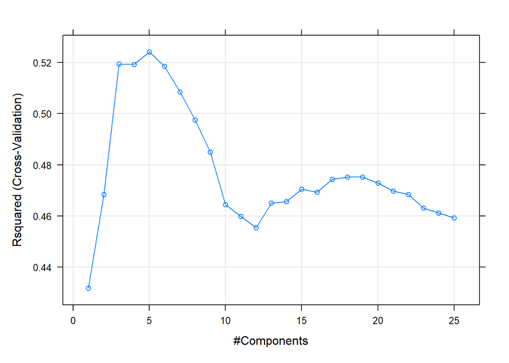

```r
plot(P_fit2)
```

The optimal value for the performance metric yields a RMSE of 1.07 and R2 of 0.524.

**(d) Predict the response for the test set. What is the value of the performance metric and how does this compare with the resampled performance metric on the training set?**

```r
P_predict2 <- predict(P_fit2, newdata=test_x2)
(postResample(pred=P_predict2, obs=test_y2))
```

```
##      RMSE  Rsquared       MAE
## 0.6344353 0.6718573 0.5241329
```

**(e) Which predictors are most important in the model you have trained? Do either the biological or process predictors dominate the list?**

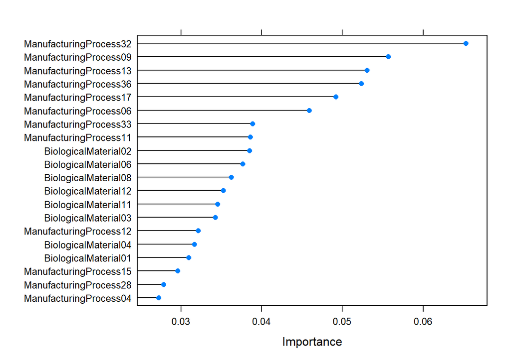

```r
plot(varImp(P_fit2, scale = FALSE), top=20, scales = list(y = list(cex = 0.8)))
```

**(f) Explore the relationships between each of the top predictors and the response. How could this information be helpful in improving yield in future runs of the manufacturing process?**

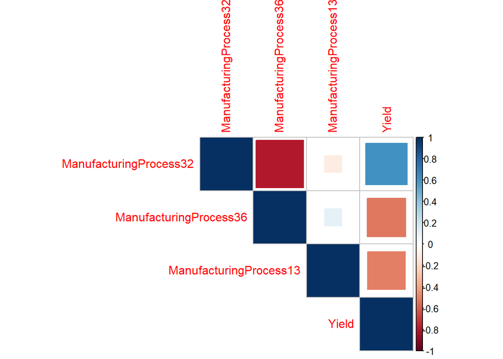

```r
correlation <- cor(select(CHEM_dataframe2, 'ManufacturingProcess32','ManufacturingProcess36','ManufacturingProcess13','Yield'))
corrplot::corrplot(correlation, method='square', type="upper")
```